# QTM 151 - Quiz 1

## Try to submit as an HTML file

```python
# Write your answer here
print('Rachel Wang')
```

```
Rachel Wang
```

This quiz is open book

- You can use the lecture notes
- You will get partial credit for attempting the questions
- To get full credit, the code should your run as intended
- You should NOT communicate with other students

Print the following message:

"I will abide by Emory's code of conduct"

**By printing the message, you acknowledge that you will abide by Emory's code of conduct.**

```python
# Write your answer here:
print("I will abide by Emory's code of conduct")
```

```
I will abide by Emory's code of conduct
```

Import the libraries "numpy", "matplotlib.pytplot", and "pandas"

```python
# Write your answer here
import pandas as pd
import numpy as np
import matplotlib.pyplot as plt
```

## Part I: Visualizing Random Variables

(a) Create two random variables ...

- Call them "vec_x" and "vec_z"
- Generate "vec_x" from a uniform distribution with (low = 10, high = 20, size = 1000)
- Generate "vec_z" from a chi-square distribution with (df = 1, size = 1000)
- Plot a histogram of each variable
  - Label the axes and title
  - Each graph should have a different title

To get full points, plot the histograms on a grid (See Lecture 6)

[figure not shown]

```python
# Write your own code:
vec_x    = np.random.uniform(low = 10,high = 20, size = 1000)
vec_z    = np.random.chisquare(df = 1, size = 1000)
fig, list_subfig = plt.subplots(1, 2,figsize = (6,3))
list_subfig[0].hist(x = vec_x)
list_subfig[0].set_title("Uniform Distribution of Vector X")
list_subfig[0].set_xlabel("Value")
list_subfig[0].set_ylabel("Frequency")

list_subfig[1].hist(x = vec_z)
list_subfig[1].set_title("Uniform Distribution of Vector Z")
list_subfig[1].set_xlabel("Value")
list_subfig[1].set_ylabel("Frequency")
```

(b) Create a new variable "vec_y" by the formula

$ y = e^x + 2x + 5$

- Use element-by-element vector operations (no loops)
- Produce a scatter plot of "vec_y" against "vec_x"
- Label the axes and the title
- Change the color to "red", "green" or "purple" (you choose)

Hint: You can use the numpy "exp()" function with vector arrays

[output not shown]

[output cut: 195 more lines]

[output not shown]

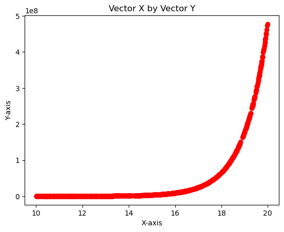

```python
# Write your own code:
vec_y = np.exp(vec_x) + 2 * vec_x + 5
print(vec_y)

plt.scatter(vec_x, vec_y, color = "red")
plt.xlabel("X-axis")
plt.ylabel("Y-axis")
plt.title("Vector X by Vector Y")
```

## Part II: Operations over multiple datasets

(c) Creates two lists with ...

- The names of the datasets
- The years of the datasets (type manually based on the dataset names)

To answer this question, you need to browse the Quiz folder

You will find three datasets on the distribution of ages worldwide

```python
# Write your own code
name_list = ['wdi_ages1980', 'wdi_ages2000', 'wdi_ages2020']
year_list = [1980, 2000, 2020]
```

(d) Create a loop that ...

$\qquad$ "This dataset contains information on or after 2000.

- If the year $<$ 2000, print the message

$\qquad$ "This dataset contains information before 2000"

```python
# Write your own code
# Write your own code
for i in year_list:
    if i >= 2008:
        print('This dataset contains information on or after 2008')
    else:
        print('This dataset contains information before 2008')
```

[output not shown]

(e) Your goal is to convert all the ".csv" data files to ".xlsx" (Excel) files

- **Before answering** this question do use your terminal (in Mac) or Anaconda prompt (in windows) to install the following package: `conda install openpyxl`
- Create a list with the ".csv" dataset names (including their relative subfolder "data_quiz/)
- Create a new list called "list_newnames", with each element ending in ".xlsx" (including the subfolder "data_excel/")
- Start an index

$\qquad$ index = 0

- Initiate a for loop over the list of dataset names. Inside the loop:
  - Read the ".csv" dataset and store it in an object called "dataset"
  - Create a variable called "filename" from the "list_newnames", extracting the element "index"
  - Store "dataset" as an excel file with name "filename".

  $\qquad$ index = index + 1

Note: Check that you did it correctly by trying to open your new excel files outside "VSCode"

```python
# Write your own code:
list_csv = ["data_quiz/wdi_ages1980.csv", "data_quiz/wdi_ages2000.csv", "data_quiz/wdi_ages2020.csv"]
list_newnames = [csv.replace(".csv", ".xlsx").replace("data_quiz/", "data_excel/") for csv in list_csv]

index = 0
for csv_filename in list_csv:
    dataset = pd.read_csv(csv_filename)
    filename = list_newnames[index]
    dataset.to_excel(filename, index = False)
    index = index + 1
```

```python
# Write your own code:
```

(f) Your goal is to open each dataset, create a new variable, then plot

- Create a list with the ".csv" dataset names (including their relative subfolder "data_quiz/)
- Start an index

$\qquad$ index = 0

- Initiate a for loop over the list of dataset names. Inside the loop:
  - Read the dataset and store it in an object called "dataset"
  - Create two new variables as

  $\qquad$ percent_ages0to14 = dataset["percent_ages0to14"]  
  $\qquad$ percent_ages15to64 = dataset["percent_ages15to64"]
  - Calculate the percent of the population between ages 0 and 64 by adding the two previous variables
  - Plot a histogram and label the axes
  - Use plt.show() to display the plot
  - Write

  $\qquad$ index = index + 1

This should produce a histogram for each dataset

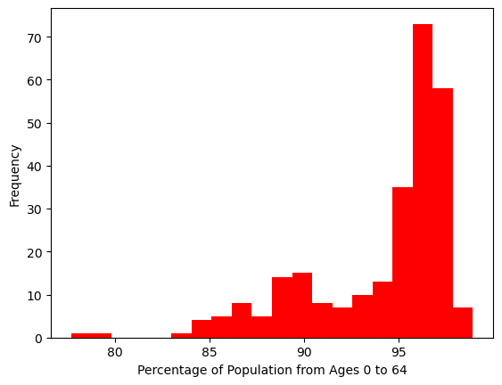

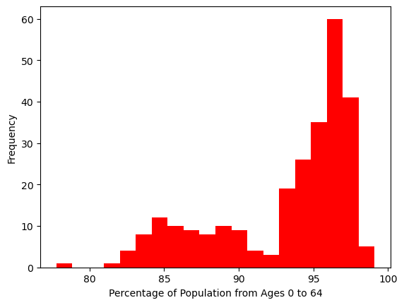

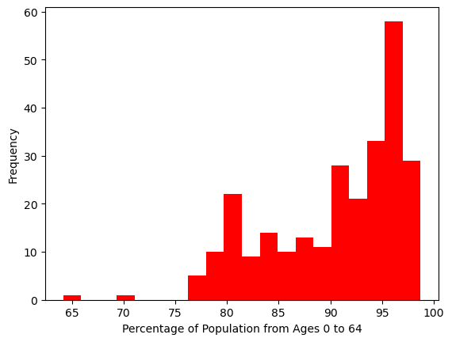

```python
# Write your own code:

index = 0

for csv_filename in list_csv:
    dataset = pd.read_csv(csv_filename)
    percent_ages0to14 = dataset["percent_ages0to14"]
    percent_ages15to64 = dataset["percent_ages15to64"]
    percent_ages0to64 = percent_ages0to14 + percent_ages15to64
    plt.hist(percent_ages0to64, bins=20, color='red')
    plt.xlabel("Percentage of Population from Ages 0 to 64")
    plt.ylabel("Frequency")
    plt.show()
    index = index + 1
```